# K-Nearest Neighbors (KNN)

## KNN in SAS Enterprise Miner

- In SAS Enterprise Miner, KNN is the **Memory-Based Reasoning (MBR)** node, on the **Model** tab.
- “Memory-based” = the same idea as a lazy learner: the model *is* the stored training data.
- The MBR node measures closeness with **Euclidean distance**.
- It needs **numeric** inputs on the **same scale**, with no missing values. So in the diagram, we prepare the inputs *before* the MBR node.

Same algorithm, different interface: in Python we write `KNeighborsClassifier(n_neighbors=K)`; in SAS we drag an MBR node into the diagram and set **Number of Neighbors** $= K$.

## In SAS Enterprise Miner: Add Principal Components

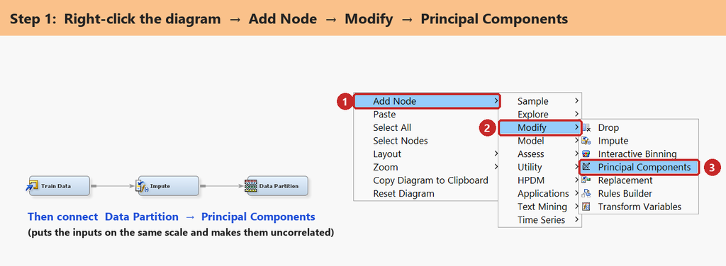

## In SAS Enterprise Miner: Add the MBR (KNN) Node

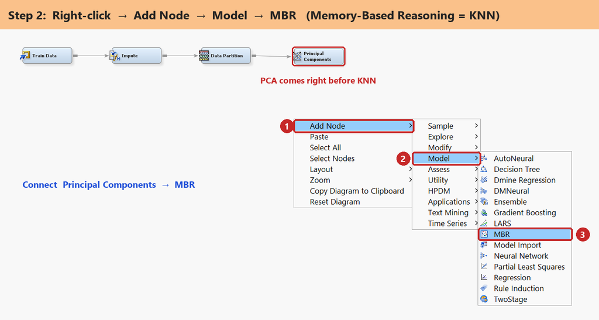

## In SAS Enterprise Miner: Set $K$

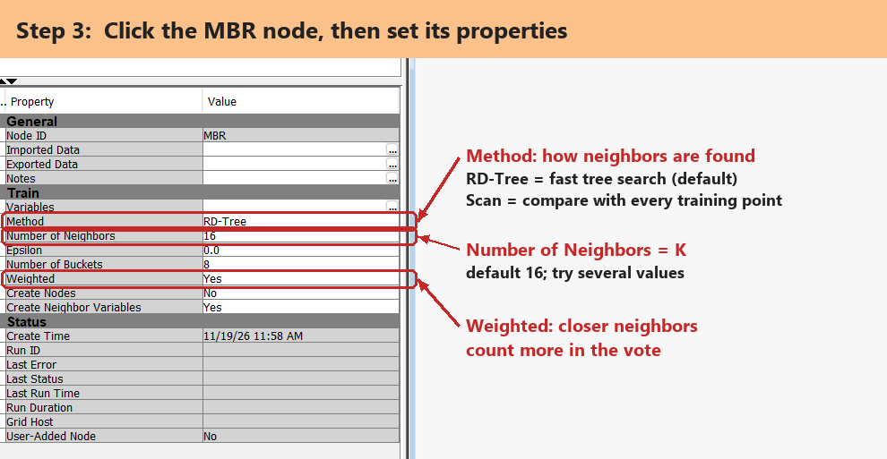

## In SAS Enterprise Miner: Run and See Results

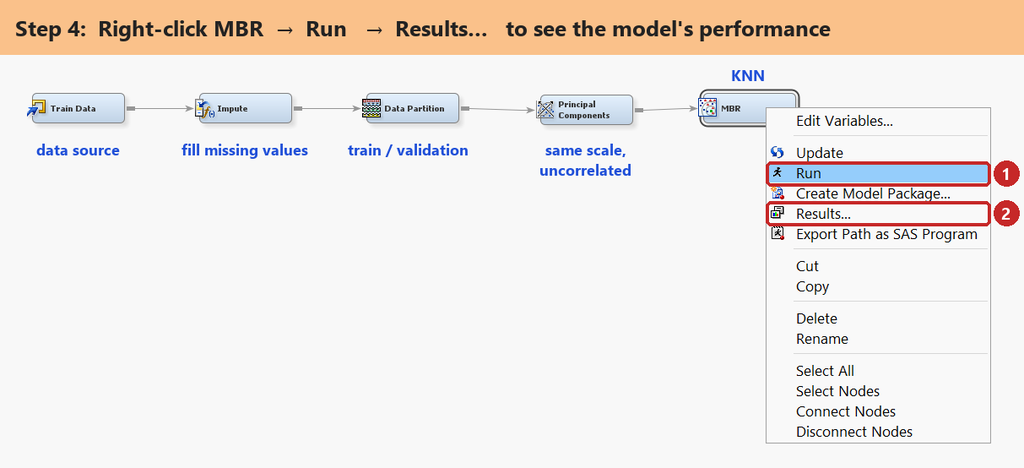

## The Process Flow Diagram

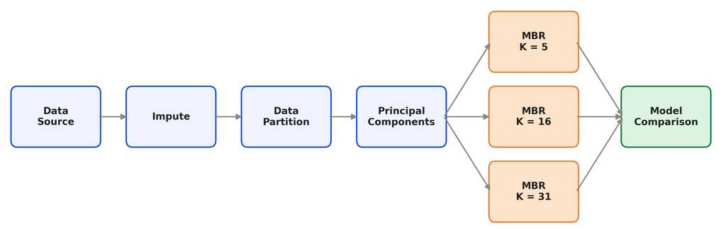

- Each box is a node; the arrows pass the data from left to right.
- Three MBR nodes with different $K$ run side by side, and **Model Comparison** picks the best one.

## Step by Step

1. **Data Source**: create the data source and set the roles: the target variable gets role **Target**; the predictors get role **Input**; ID-type columns get role **Rejected**.
2. **Impute**: fill in missing values. KNN needs a value for every input to compute a distance.
3. **Data Partition**: split the data into training and validation (and test) sets. The default is 40% / 30% / 30%.
4. **Principal Components**: turns the inputs into new numeric variables that are on the same scale and uncorrelated. This is the input preparation SAS recommends for the MBR node, and it plays the role of **standardizing** in our KNN algorithm (Step 1).
5. **Memory-Based Reasoning**: set **Number of Neighbors** ($K$). Add more MBR nodes with other values of $K$.
6. **Model Comparison**: connect all MBR nodes; it picks the model with the best **validation** performance (for example, the lowest misclassification rate).
7. **Run** the diagram from Model Comparison, then right-click a node and choose **Results**.

## Why Principal Components Before KNN?

In SAS EM, the MBR node is **usually run after Principal Components**:

- **Same scale**: no variable dominates the distance.
- **Uncorrelated**: overlapping inputs are not counted twice.
- **Fewer dimensions**: KNN works better with fewer columns, and the search is faster.

Use the **correlation** matrix; keep enough components to explain about 80–90% of the variance.

## Key Settings of the MBR Node

| Property | What it means | KNN idea |
| --- | --- | --- |
| **Number of Neighbors** | how many neighbors vote (default $16$) | $K$ |
| **Method: Scan** | compares the new point with **every** training point | exactly our algorithm (Steps 2–4) |
| **Method: RD-Tree** (default) | organizes the training data in a tree to find neighbors faster | same neighbors, faster search on large data |
| Distance | always **Euclidean** | the distance function |

**No cosine option?** Use what we showed earlier: cosine similarity = Euclidean distance after scaling every row to length 1. Normalize the rows first (for example, in a SAS Code node), and the MBR node’s Euclidean neighbors are the cosine neighbors.

## Choosing $K$ in SAS

- Copy the MBR node and change **Number of Neighbors**: for example $K = 5, 16, 31$ (odd $K$ avoids ties for a binary target).
- Connect them all to **Model Comparison**. It ranks the models on the **validation** data.
- This is the same idea as the training vs. test error plot: small $K$ overfits, large $K$ underfits, and the validation data picks the $K$ in between.

The validation data in SAS plays the role of the test data (or cross-validation) in Python: never choose $K$ on the training data, where $K = 1$ always looks perfect.